# RTBL_Exercises

### Importing and barcharts

Import the csv

Load libraries (dplyr and ggplot2)and read in the rbbl to a dataframe called rtbl

```r
rtbl <- read.csv("STG_RTBL20170623_DUMMYDATA.csv",header=TRUE)
```

If we want to do a plot based on the app stratus, we get this:

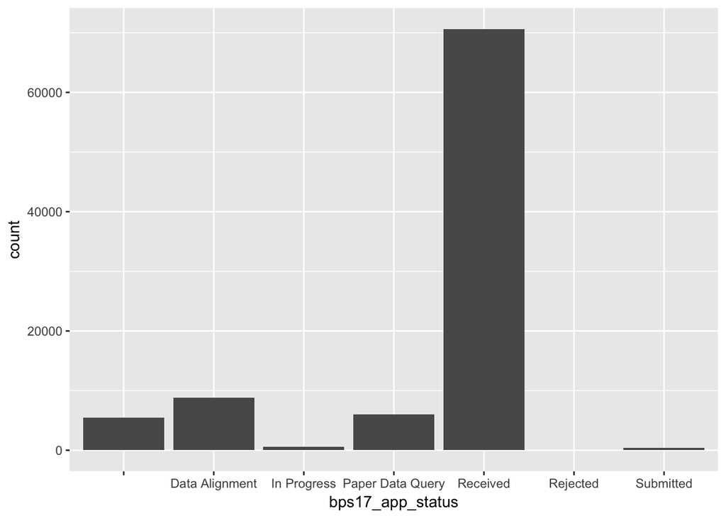

```r
ggplot(rtbl,aes(x=bps17_app_status)) +
  geom_bar()
```

Note the 1st col, which is populating blanks. To get rid of this we can change all the blanks to NA in the dataframe

```r
rtbl[rtbl==""] <- NA
```

Now if we run the plot the blanks have become NAs, so are ignored in the output when we use the !is.na function to filter them out

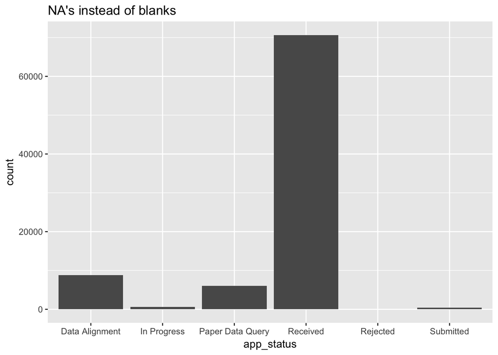

```r
ggplot(rtbl[!is.na(rtbl$bps17_app_status),],aes(x=bps17_app_status)) +
  geom_bar() +
  labs(x = "app_status",title="NA's instead of blanks")
```

So what else can we do?

We could split the bars using fill= in the aes.

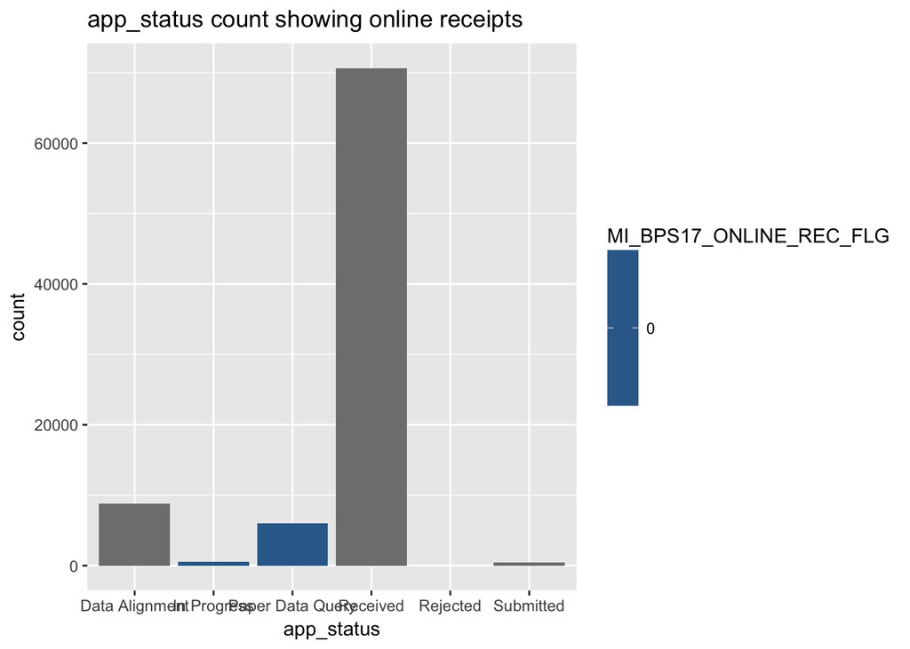

```r
ggplot(rtbl[!is.na(rtbl$bps17_app_status),],aes(x=bps17_app_status,fill=MI_BPS17_ONLINE_REC_FLG)) +
  geom_bar() +
  labs(x = "app_status",title="app_status count showing online receipts")
```

That doesn’t seem to work. Let’s see what type of data it is, as it has to be a factor with levels and not something like a number.

```r
class(rtbl$MI_BPS17_ONLINE_REC_FLG)
```

```
## [1] "integer"
```

We need to change it to a type that has limited values, like a *factor*, which has levels rather than being a continous data type. So we change it to a factor.

```r
rtbl$MI_BPS17_ONLINE_REC_FLG <- as.factor(rtbl$MI_BPS17_ONLINE_REC_FLG)

class(rtbl$MI_BPS17_ONLINE_REC_FLG)
```

```
## [1] "factor"
```

So now when we trt to FILL with MI_BPS17_ONLINE_REC_FLG we get a better result

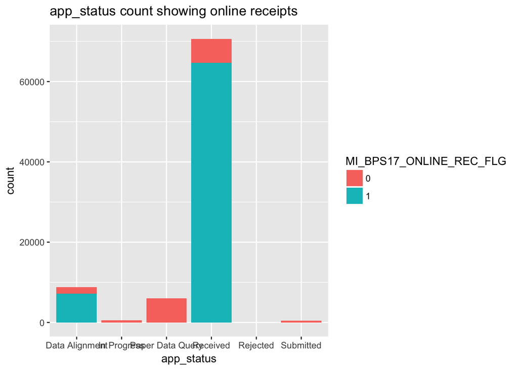

```r
ggplot(rtbl[!is.na(rtbl$bps17_app_status),],aes(x=bps17_app_status,fill=MI_BPS17_ONLINE_REC_FLG)) +
  geom_bar() +
  labs(x = "app_status",title="app_status count showing online receipts")
```

Rather than splitting the bars, we can plot them alongside each other with *facets*. Note the tilde and the ., denoting the order and positioning of the panels. The facet item cannot be a continuous data type. More on facets here: https://plot.ly/ggplot2/facet/

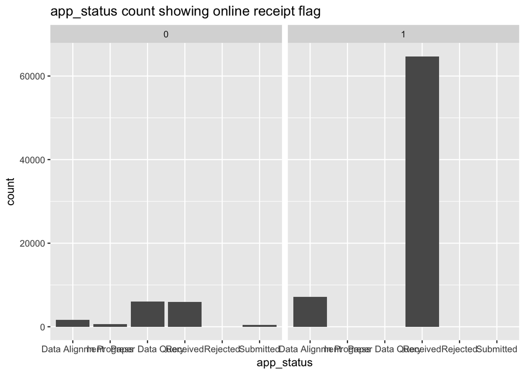

```r
ggplot(rtbl[!is.na(rtbl$bps17_app_status),],aes(x=bps17_app_status)) +
  geom_bar() +
  labs(x = "app_status",title="app_status count showing online receipt flag") +
  facet_grid(.~MI_BPS17_ONLINE_REC_FLG)
```

How about a line graph? For these, the line must be continuous, and you need to specify an x and a y measure. We could do with using a date column such as MI_BPS17_RECEIPT_DT.

```r
class(rtbl$MI_BPS17_RECEIPT_DT)
```

```
## [1] "factor"
```

So we change to a date. To do this we have to specify what format the date is currently in so it can interpret the values it finds.

```r
rtbl$MI_BPS17_RECEIPT_DT <- as.Date(rtbl$MI_BPS17_RECEIPT_DT, format = "%d/%m/%Y %H:%M")

class(rtbl$MI_BPS17_RECEIPT_DT)
```

```
## [1] "Date"
```